# Child Abuse in Iowa: Stopping Tomorrow’s Abuser by Protecing Today’s Abusee

Group 4: Ratie Vushe and Jinghan Gao

November 30th, 2018

# A Worldwide Problem

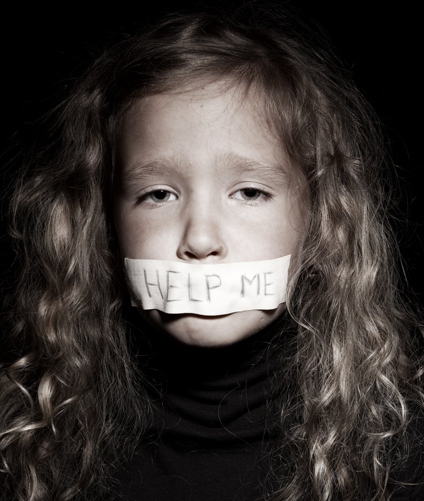

Religious News Service

Crime is constantly increasing and while child abuse might have drowned amongst other forms of crime, it still continues to be a complication- having more than 3 million reports of child abuse are made in the United States per year 1. It is a worldwide problem that occurs across all racial, cultural, or social groups. Child abuse can be simply classified as physical, emotional, or sexual, but all has the capability of scarring children for a lifetime. Most people believe that child abuse is as a result of action, be it physical, sexual or exposure to dangerous substances; but inaction in the form of denial of critical care or negligence can also cause immense harm to children people often overlook this. Without paying enough attention and consideration to our future generation, the consequence could be drastically adverse, varying from Intergenerational transmission of abuse to suicidal behaviors 2. The most effective way to curb future child abuse is to protect today’s children because a third of victims of child abuse become abusers themselves afterwards 3. Using population and child abuse data we perform analysis into child abuse in Iowa and recommend policy changes to improve the situation.

## Background information

The dataset was found on Waggle and it summarizes the occurrences of different types of child abuse in the counties of Iowa from 2004 to 2017. Data is grouped by calendar year, county and type of abuse. Iowa is divided into several DHS Service areas (Department of Homeland Security (DHS) Service area), which are federal agencies designed to protect the respective counties against threats.

# Thought Process

We first looked at the total occurences of child abuse in each county in Iowa in 2017. By using a static map we created a display of the degree of child abuse in each county; with the darkest shades representing by the most reports of child abuse and the light areas representing otherwise. We further divided up the counties into service areas denoted by numbers 1, 2, 3, 4, 5 on map as shown. There are ninety nine counties in Iowa, meaning that in average, 19.8 counties share the same service area. On the map, more than half of the darker counties are under Service Area 2, which indicates there are high rates of abuse in the Northern County. This may be a result of poor service quality in this region of Iowa. Generally speaking, we can arrange the service areas by quality to obtain: 2 < 1 < 4 < 5 < 3 (with 2 providing the least quality and 3 having the highest quality)

## Most Common Abuse Type

We did some data wrangling to find the most occurring type of abuse in each county and to our surprise Denial of Critical Care was the most popular across all counties, having significant intensity in each service area.

| Year | FIPS.County.Code | County.Name | DHS.Service.Area | Judicial.District | Abuse.Type | Occurences | delete | latitude | longitude | delete2 | US.Counties | Iowa.Watersheds..HUC.10. | Iowa.Watershed.Sub.Basins..HUC.08. | Iowa.ZIP.Code.Tabulation.Areas | Service.Area |
| --- | --- | --- | --- | --- | --- | --- | --- | --- | --- | --- | --- | --- | --- | --- | --- |
| 2017 | 19177 | Van Buren | 4-Cedar Rapids | 8-Eigth JD | Denial of Critical Care (Neglect) | 18 |  | 40.75323 | -91.94999 |  | 1885 | 368 | 30 | 798 | 4 |
| 2017 | 19035 | Cherokee | 1-Western | 3-Third JD | Denial of Critical Care (Neglect) | 34 |  | 42.73562 | -95.62381 |  | 181 | 429 | 37 | 286 | 1 |
| 2017 | 19145 | Page | 1-Western | 4-FourthJD | Denial of Critical Care (Neglect) | 79 |  | 40.73914 | -95.15017 |  | 1837 | 463 | 46 | 598 | 1 |
| 2017 | 19089 | Howard | 2-Northern | 1-First JD | Denial of Critical Care (Neglect) | 56 |  | 43.35677 | -92.31720 |  | 1788 | 13 | 6 | 429 | 2 |
| 2017 | 19077 | Guthrie | 1-Western | 5-FifthJD | Denial of Critical Care (Neglect) | 38 |  | 41.68375 | -94.50105 |  | 1784 | 336 | 28 | 310 | 1 |
| 2017 | 19079 | Hamilton | 2-Northern | 2-Second JD | Denial of Critical Care (Neglect) | 37 |  | 42.38377 | -93.70681 |  | 281 | 122 | 11 | 782 | 2 |
| 2017 | 19025 | Calhoun | 2-Northern | 2-Second JD | Denial of Critical Care (Neglect) | 25 |  | 42.38518 | -94.64041 |  | 1371 | 326 | 27 | 121 | 2 |
| 2017 | 19161 | Sac | 1-Western | 2-Second JD | Denial of Critical Care (Neglect) | 41 |  | 42.38626 | -95.10539 |  | 1880 | 324 | 27 | 97 | 1 |
| 2017 | 19101 | Jefferson | 4-Cedar Rapids | 8-Eigth JD | Denial of Critical Care (Neglect) | 109 |  | 41.03176 | -91.94888 |  | 285 | 147 | 13 | 326 | 4 |
| 2017 | 19143 | Osceola | 1-Western | 3-Third JD | Denial of Critical Care (Neglect) | 24 |  | 43.37857 | -95.62369 |  | 1836 | 421 | 37 | 597 | 1 |

# Intensity of Child abuse in Iowa

We first looked at the total number of child abuse that occurred in each county in Iowa in 2017. By using a static map we created a display of the degree of child abuse in each county; with the darkest shades representing by the most reports of child abuse and the light areas representing otherwise. We further divided up the counties into service areas denoted by numbers 1, 2, 3, 4, 5 on map as shown. There are ninety nine counties in Iowa, meaning that in average, 19.8 counties share the same service area. On the map, more than half of the darker counties are under Service Area 2, which indicates there are high rates of abuse in the Northern County. This may be a result of poor service quality in this region of Iowa. Generally speaking, we can arrange the service areas by quality to obtain: 2 < 1 < 4 < 5 < 3 (with 2 providing the least quality and 3 having the highest quality)

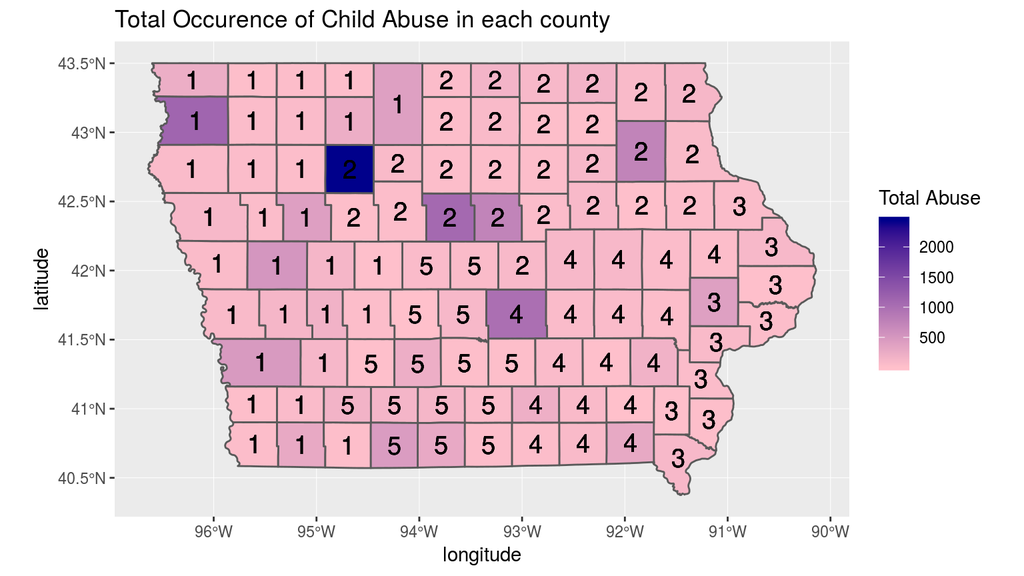

# Types of Abuse Across States

[interactive chart not shown]

# Abuse Across the Years

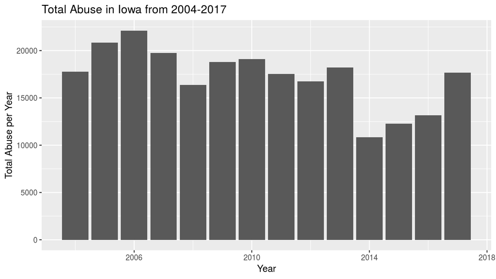

# Policy Changes

Given the information the above plots have provided us, we recommendation the following policy changes for the State of Iowa:

*Increase education on child abuse; particularly for Neglect and Dangerous Substances.* Increase the quality of service area 2 by training. *Increase the number of service areas as some of them encompass too many counties.* Issue new laws that make it more difficult to prevent underage children from obtaining dangerous substances such as drugs or alcohol. (This could mean raising legal drinking age) *Increasing social services to provide safer spaces as most abuse happens in the home.

## Conclusion

To date the financial cost of child abuse and neglect in the United States is a approximately $585 billion and we believe that millions could be saved in the future by implementing the above policy changes today that would not cost half as much.

# References and Citations

- [The Issue of Child Abuse](https://www.childhelp.org/child-abuse/), n.d. *[Effects of child abuse and neglect for adult survivors](https://aifs.gov.au/cfca/publications/effects-child-abuse-and-neglect-adult-survivor) , 2014, January.* [Sad Legacy Of Abuse: The Search For Remedies] (https://www.nytimes.com/1989/01/24/science/sad-legacy-of-abuse-the-search-for-remedies.html) , JAN. 24, 1989
- [Medical Marijuana use in Iowa] (https://420intel.com/regional/iowa), Oct.01.2018
- [United States Cencus Bureau(https://www.census.gov/quickfacts/iowacountyiowa)